# Tutorial for R packge **`htlgmm`**: Heterogeneous Transfer Learning Dealing with Unmatched Features

Ruzhang Zhao, Nilanjan Chatterjee

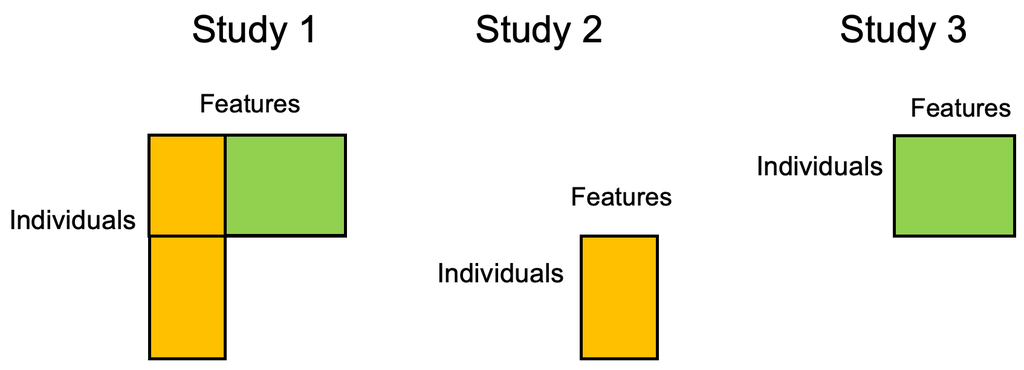

This tutorial serves as an introduction of HTL-GMM method (Heterogeneous Transfer Learning with Generalized Method of Moments). We will introduce the R package usage and some application examples.

# **Installation**

```r
devtools::install_github("RuzhangZhao/htlgmm")
```

# **Method Recap**

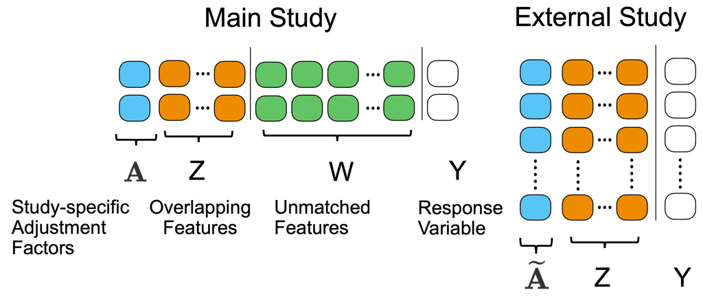

- Main study and external study can from the same or different population.
- External study can be in the form of individual data or trained model with parameter estimation.

# **Usage of Package `htlgmm`**

### **Quick review of R package `glmnet`**

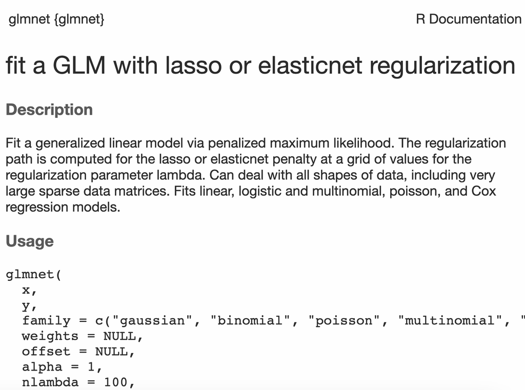

## **Primary Functions of package `htlgmm`**

Functions **`htlgmm`** and **`cv.htlgmm`** work similarly like functions **`glmnet`** and **`cv.glmnet`** from R package **`glmnet`**. **`cv.glmnet`**/**`cv.htlgmm`** does cross validation with an automatically generated tuning parameter list to select tuning parameters. We recommend users to use `cv.htlgmm` without knowing prefixed tuning parameters.

## **Simple Examples**

The simulation example is to illustrate how the `cv.htlgmm` method is implemented, compared with `cv.glmnet`. The simulation is performed under both linear and logistic regression settings. We use **20** overlapping features (**Z**) and **3** unmatched features (**W**). 3/20 of **Z** whose effects on outcome are nonzero, while 2/3 of **W** whose effects on outcome are nonzero.

### **Simulation Setup**

```r
library(htlgmm)
pZ=20 # overlapping features
pW=3 # unmatched features
coef<-c(rep(0,pZ+pW))
coef[1:3]<-0.5
coef[c(21,22)]<-0.5
which(coef!=0)
```

```
## [1]  1  2  3 21 22
```

Main study sample size **n** is 400, while external study sample size **nE** is 2000.

```r
n=400
nE=2000
n_joint=n+nE
main_index<-1:n
```

We jointly generate main and external studies.

```r
set.seed(2023)
Z_joint<-matrix(rnorm(n_joint*pZ),n_joint,pZ)
colnames(Z_joint)<-paste0("Z",1:pZ)
W_joint<-matrix(rnorm(n_joint*pW),n_joint,pW)
colnames(W_joint)<-paste0("W",1:pW)
Z<-Z_joint[main_index,]  # separate main and external study for Z
ZE<-Z_joint[-main_index,]

W<-W_joint[main_index,] # only need main study for W
```

**y** is generated with both **Z** and **W**.

```r
y_joint<-cbind(Z_joint,W_joint)%*%coef+rnorm(n_joint,0,1)
y<-y_joint[main_index] # separate main study y
yE<-y_joint[-main_index] # separate external study y
```

Display the data structure of main study **(y,Z,W)**.

```r
main_study<-cbind(y,Z,W)
head(main_study,2)
```

```
##
##               y          Z1         Z2         Z3         Z4
## [1,]  0.1583804 -0.08378436 -0.1616781 -1.3225585 -0.8951142
## [2,] -1.5600714 -0.98294375 -0.6106287 -0.2736024 -1.5626956
##              Z5          Z6          Z7        Z8         Z9
## [1,]   1.383318   -1.238603 -0.41577864 2.2262279 -0.4355437
## [2,]  -1.532501    2.672741 -0.03547315 0.5557817 -2.6988094
##             Z10         Z11         Z12        Z13        Z14
## [1,] -1.2781105  0.09987105  -0.1749688  0.1048335  0.2623919
## [2,] -0.9780216  1.12832300  -1.7289105 -1.9954020 -0.4474806
##             Z15         Z16         Z17        Z18        Z19
## [1,]   2.477921  0.34783666    0.504284 -0.6407976   1.750567
## [2,]  -1.173848 -0.03577785   -1.899115  0.9483486   0.452172
##             Z20          W1          W2       W3
## [1,] -1.3606713  -0.1165617  0.7678237  1.383503
## [2,] -0.4931382  -0.9528922  0.7417592  1.648957
```

Display the data structure of external study **(yE,ZE)**.

```r
external_study<-cbind(yE,ZE)
head(external_study,2)
```

```
##
##              yE         Z1         Z2         Z3        Z4
## [1,] -0.7521167 -0.5272182 -0.6934707 -0.4671187  1.690280
## [2,] -0.5669488  0.4289935 -0.9329976 -1.2707116 -1.873718
##             Z5         Z6        Z7         Z8          Z9
## [1,]  1.696264 0.00194452 -0.565544  0.3158803   0.8435341
## [2,]  0.192479 0.05867523  1.316755 -2.9078613   0.2431169
##             Z10        Z11       Z12        Z13        Z14
## [1,]  0.4943649 -0.9205529  1.557621 -0.4550360 -0.1501486
## [2,] -1.2291510  0.1720111  1.082391 -0.2680297 -1.3407530
##             Z15        Z16       Z17        Z18        Z19
## [1,] -0.8853446 -1.4658571 0.2602220 -0.8654340 -0.3140345
## [2,]  2.3817827  0.4602121 0.3496314  0.5179547  0.2368451
##             Z20
## [1,]  -0.202401
## [2,]   1.286966
```

Scale the **Z** and **W** predictors

```r
Z<-scale(Z)
ZE<-scale(ZE)
W<-scale(W)
```

## **How `cv.glmnet` works**

We do `cv.glmnet` for lasso only on main study.

```r
library(glmnet)
res_glmnet<-cv.glmnet(x=cbind(Z,W),y=y)
est_coef_glmnet<-coef.glmnet(res_glmnet,s="lambda.min")[-1] # without intercept
```

## **Train with External Study**

Summarize external study to be trained model with parameter estimation. Here we use OLS with external study **(yE,ZE)**. Extract estimated coefficients (other than intercept terms, only for **Z**), variance-covariance matrix, and external study sample size. Convert the results into list.

```r
reslm<-lm(y~.,data = data.frame(y=yE,ZE))
study_external = list(
                Coeff=reslm$coefficients[-1],
                Covariance=vcov(reslm)[-1,-1],
                Sample_size=nE)
study_info<-list()
study_info[[1]] <- study_external # The study_info is also a list because we can support multiple external studies.
```

Remove intercept term by centering y to make problem easier in the main study.

```r
y<-scale(y,center = TRUE, scale = FALSE) # only do centering for main study y.
```

## **Key Parameter List of Function `cv.htlgmm`**

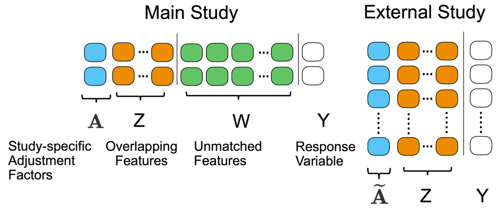

- **y** : Response Variable.
- **Z** : Overlapping Features.
- **W** : Unmatched Features.
- **study_info** : Parameter estimation from External study regarding overlapping features. “study_info” comes as list, including the information of estimated coefficient, estimated variance (variance-covariance matrix), external study sample size.
- **family** : Currently focus on linear (“gaussian”) and logistic (“binomial”).
- **A** : Study-specific Adjustment Factors.
- **penalty_type** : Select from c(“lasso”,“adaptivelasso”,“ridge”)
- **use_sparseC** : Whether to use approximate version of weighting matrix C. Default is FALSE.
- **inference** : Conduct post-selection inference for adaptive lasso penalty only. Default is FALSE.

## **Function Help Page**

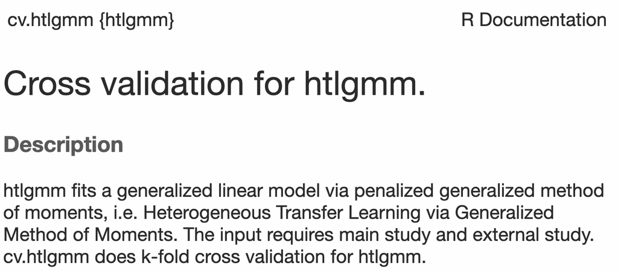

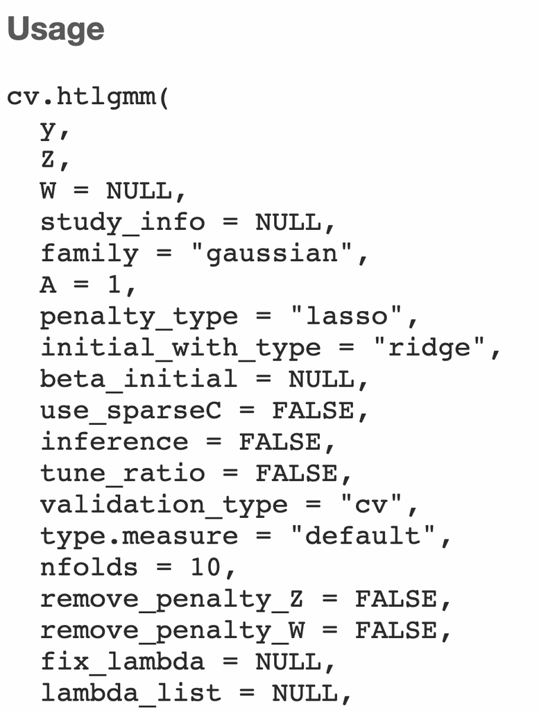

## **Implementation of `cv.htlgmm` on example**

Following the main input list of `cv.htlgmm`, we use the input of **y**, **Z** for overlapping features, **W** for unmatched features, **study_info** for external study information, **family** which is default for gaussian, **use_sparseC** for limited main study size and faster computation.

```r
res_htlgmm<-cv.htlgmm(y=y,
                      Z=Z,
                      W=W,
                      study_info = study_info,
                      family = "gaussian",
                      penalty_type = "lasso",
                      use_sparseC = TRUE)

res_htlgmm_ada<-cv.htlgmm(y=y,
                      Z=Z,
                      W=W,
                      study_info = study_info,
                      family = "gaussian",
                      penalty_type = "adaptivelasso",
                      use_sparseC = TRUE,
                      inference = TRUE)
```

## **Output list of `cv.htlgmm`**

- **beta** : Target coefficient estimation. The coefficients go with the order of (Z,W,A).
- **lambda_list**: The lambda list for validation.
- **cv_mse**: The mean square error(mse) when family = “gaussian”, and validation_type = “cv”.
- **cv_dev**: The deviance(dev) when family = “binomial”, and validation_type = “cv”. For each lambda, cv_dev is the average deviance across all folds.
- **cv_auc**: The area under ROC curve(auc) when family = “binomial”, and validation_type = “cv”. An alternative choice of cv_dev.
- **lambda_min**: The selected best lambda.
- **corrected_pos**: For post-selection inference, they are the corrected position passing significant level 0.05 after BH adjustment (Benjamini & Hochberg).
- **nonzero_pos**: For estimated beta, the nonzero positions.
- **pval**: For nonzero_pos, the calculated p values.
- **nonzero_var**: For nonzero_pos, the calculated variances.

Go over the output list one by one.

- **beta** : Target coefficient estimation. The coefficients go with the order of (Z,W,A).

```r
est_coef_htlgmm<-res_htlgmm$beta
names(est_coef_htlgmm)<-c(paste0('Z',1:pZ),paste0('W',1:pW))
est_coef_htlgmm
```

```
##
##          Z1          Z2          Z3          Z4          Z5
##  0.49103620  0.45601098  0.55121377 -0.02127925  0.00000000
##          Z6          Z7          Z8          Z9         Z10
## -0.03697756  0.00000000  0.01548256  0.00000000 -0.02891983
##         Z11         Z12         Z13         Z14         Z15
##  0.00000000  0.00000000  0.04816755  0.00000000 -0.03866365
##         Z16         Z17         Z18         Z19         Z20
##  0.00989276  0.00000000  0.00000000  0.00000000  0.00000000
##          W1          W2          W3
##  0.41895704  0.50850378 -0.05398813
```

```r
print("The predictos whose effects on outcome are nonzero.")
print(c(paste0('Z',1:pZ),paste0('W',1:pW))[coef!=0])
```

```
## [1] "The predictos whose effects on outcome are nonzero."
## [1] "Z1" "Z2" "Z3" "W1" "W2"
```

```r
print('HTLGMM selected_vars')
print(res_htlgmm_ada$selected_vars)
```

```
## [1] "HTLGMM selected_vars"
## $position
##  [1]  1  2  3  4  6 10 13 15 16 21 22 23
##
## $coef
##  [1]  0.50406321  0.46852761  0.56343173 -0.02396043
##  [5] -0.03266721 -0.02928292  0.05490071 -0.04280402
##  [9]  0.01275545  0.43956825  0.52417797 -0.06379813
##
## $pval
##           Z1           Z2           Z3           Z4
## 3.434244e-64 2.934463e-54 1.378309e-81 4.594174e-01
##           Z6          Z10          Z13          Z15
## 2.921867e-01 3.274114e-01 6.803797e-02 1.658497e-01
##          Z16           W1           W2           W3
## 7.028673e-01 8.715034e-21 1.010691e-29 1.367534e-01
##
## $variance
##        Z1        Z2        Z3        Z4        Z6       Z10
## 0.3551721 0.3649765 0.3469292 0.4195782 0.3847242 0.3576190
##       Z13       Z15       Z16        W1        W2        W3
## 0.3620818 0.3816925 0.4472704 0.8839618 0.8572391 0.7353187
```

- **lambda_list**: The lambda list for validation.
- **cv_mse**: The mean square error(mse) when family = “gaussian”, and validation_type = “cv”.
- **cv_dev**: The deviance(dev) when family = “binomial”, and validation_type = “cv”. For each lambda, cv_dev is the average deviance across all folds.
- **cv_auc**: The area under ROC curve(auc) when family = “binomial”, and validation_type = “cv”. An alternative choice of cv_dev.

```r
head(lambda_mse_df<-data.frame(lambda=res_htlgmm$lambda_list,
                  cv_mse=res_htlgmm$cv_mse))
```

```
##      lambda   cv_mse
## 1 1.5829574 2.261889
## 2 1.4423318 2.219077
## 3 1.3141991 2.164644
## 4 1.1974492 2.116859
## 5 1.0910711 2.062130
## 6 0.9941434 1.994146
```

- **lambda_min**: The selected best lambda based on cross validation (minimum mse, minimum deviance, maximum auc).

```r
lambda_min<-res_htlgmm$lambda_min
print(lambda_min)
```

[output not shown]

Check the estimation error of coefficients for `cv.glmnet` and `cv.htlgmm`.

```r
est_coef_htlgmm<-res_htlgmm$beta
ee_htlgmm<-sum((coef-est_coef_htlgmm)^2)
ee_htlgmm<-round(ee_htlgmm,4)

ee_lasso<-sum((coef-est_coef_glmnet)^2)
ee_lasso<-round(ee_lasso,4)
print(paste0("Estimation Error: ","lasso(",ee_lasso,"); htlgmm(",ee_htlgmm,")"))
```

[output not shown]

The logistic regression based simulation

$$\text{expit} = \frac{\exp(x)}{1+\exp(x)}$$

Use the same coefficient but **binomial** distribution for **y**.

```r
y_joint<-rbinom(n=n_joint,size=1,prob=locfit::expit(cbind(Z_joint,W_joint)%*%coef))
y<-y_joint[main_index]
yE<-y_joint[-main_index]
```

Summarize external study, we use GLM for binary case.

```r
resglm<-glm(y~.,data = data.frame(y=yE,ZE),family = "binomial")
study_external = list(
                Coeff=resglm$coefficients[-1],
                Covariance=vcov(resglm)[-1,-1],
                Sample_size=nE)
study_info<-list()
study_info[[1]] <- study_external
```

Cross validation with lasso using `cv.glmnet`.

```r
library(glmnet)
res_glmnet<-cv.glmnet(x=cbind(Z,W),y=y,family="binomial")
```

Train with `cv.htlgmm`, the family is `binomial`.

```r
res_htlgmm<-cv.htlgmm(y=y,
                      Z=Z,
                      W=W,
                      family="binomial",
                      study_info = study_info,
                      use_sparseC = TRUE)
```

Check the estimation error between estimated coefficients and true coefficients.

```r
est_coef_htlgmm<-res_htlgmm$beta[-length(res_htlgmm$beta)]
ee_htlgmm<-sum((coef-est_coef_htlgmm)^2)
ee_htlgmm<-round(ee_htlgmm,4)

est_coef_lasso<-coef.glmnet(res_glmnet,s="lambda.min")[-1]
ee_lasso<-sum((coef-est_coef_lasso)^2)
ee_lasso<-round(ee_lasso,4)

print(paste0("Estimation Error: ","lasso(",ee_lasso,"); htlgmm(",ee_htlgmm,")"))
```

```
## [1] "Estimation Error: lasso(0.1668); htlgmm(0.052)"
```